# Book displays at Flourish and Blotts

#### **To answer the first question “what is the top selling books” we need to do the following**

- First we calculate how many of the same books customers bought. This number is also called support. $Support = Count(X)$
- Then we calculate frequency/relative support of books by dividing its support to total count. $Relative Support = Count(X)/N$
- Then multiple relative support to total number of books with sorting to get top twenty most popular books.

```r
basketSizes<-size(bookbaskets)
# Calculate the support for each book title
bookFreq<-itemFrequency(bookbaskets)
# Get the absolute count of book occurrences.
bookCounts <- (bookFreq/sum(bookFreq))*sum(basketSizes)
# High frequency items
orderedBooks = sort(bookCounts, decreasing = TRUE)
#head(orderedBooks, 10)

orderedBooks_df <- as.data.frame(orderedBooks)
orderedBooks_df$title <- rownames(orderedBooks_df)
rownames(orderedBooks_df) <- 1:nrow(orderedBooks_df)
colnames(orderedBooks_df) <- c("Support", "Title")
orderedBooks_df <- orderedBooks_df[c("Title", "Support")]
kable(orderedBooks_df[1:20,], caption = "Top 20 Books")
```

Top 20 Books

[output not shown]

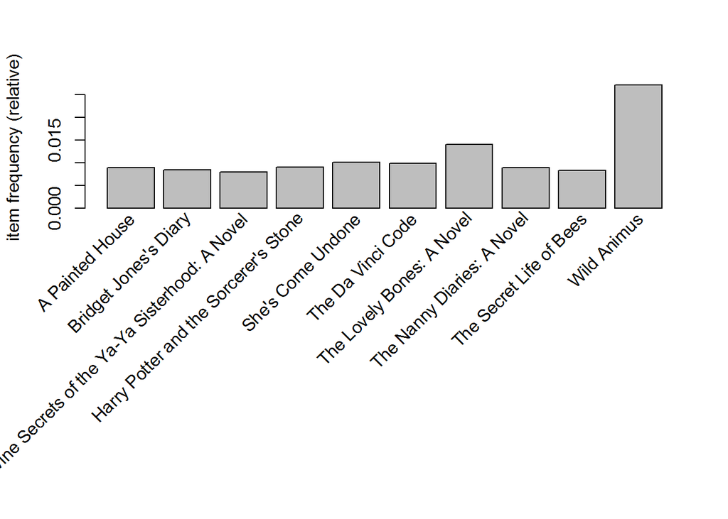

```r
#Let's plot the frequency of items
# Support number low because lower frequency on books inside dataset.
# Let's impose a rule. Let's say we only want to see items with at least 0.8% support
itemFrequencyPlot(bookbaskets, support = 0.008)
```

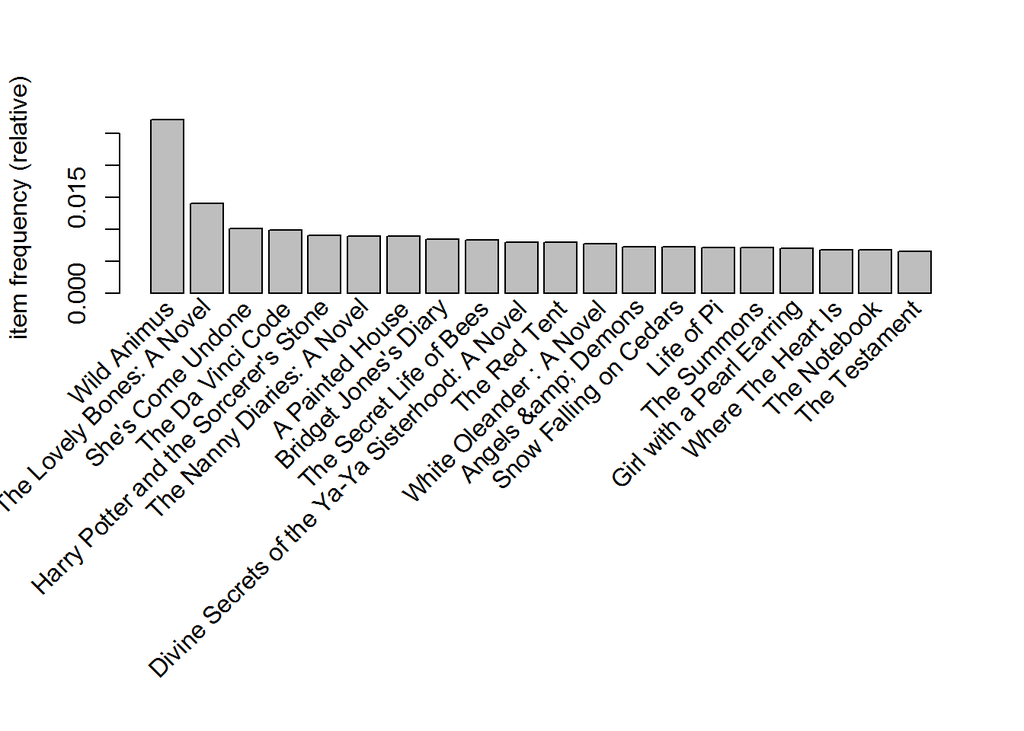

```r
#Now let's say we only want to see "top 30" items (i.e. 20 items most frequently purchased)
itemFrequencyPlot(bookbaskets, topN = 20)
```

### Model

We need an association rule model to list strong rules. For example, a customer buys book 1 also buys book 2. This is similar to recommendation feature on Amazon. We also want to remove large transactions with more than 200 books. Those larger transactions with more than 200 books are treated as outliers.  
They are not typical book store customers’ transactions. We will remove it. We also removed single book transaction because association rule needs at least two items. Association Rules by Apriori method is good for this purpose. Apriori method works well on any transaction data set. It creates a search tree of item set then prune the tree use minimal support and confidence value. The method eventually returns rules of associated items. Rules follow the format like items on left hand side return Items on the right hand side. For this rule we know associated items.

To start Apriori method first we want to keep only those transactions when customer bought more than one book.  
A single book transaction would not be useful for this model.

```r
#Only keep transactions with more than one book and let than 200 books purchased.
bookbaskets_use<-bookbaskets[basketSizes>1 & basketSizes<200]
basketSizes<-size(bookbaskets_use)
```

#### **Question 2 ask us to create a list of book for customers who follows Oprahs Book Club.**

There are seventy-six books in Oprah Book Club.  
We want to know how many of those same books also existed in the transaction data set. The Intersect two list contains fifty-six titles.

```r
oprahBookClub <- read.csv("C:/Users/lj015625/Desktop/DataMining Class/HW4/data/oprahBookClub.csv")
orderedBooks_df <- as.data.frame(orderedBooks)
length(oprahBookClub$Title)
```

```
## [1] 76
```

```r
oprahBookClub_intersect <- intersect(rownames(orderedBooks_df), oprahBookClub$Title)
length(oprahBookClub_intersect)
```

```
## [1] 56
```

If we use Oprah Book Club books on the left hand side rule of the Apriori algorithm this would give us books we should display for a typical Oprah Book Club reader. We did trial and errors and end up picking support at 0.02%, confidence at 60%, minimum length at 2, maximum length at 5. The support concept is stated in previous section. We also specify a minimal confidence number. While support measures How often does the rule happen. Confidence measures how often is the rule correct. $confidence(X->Y) = (support(X,Y))/(support(X))$

```r
oprahRule_df_total_df <- data.frame(rules=factor(),
                                        support=double(),
                                        Factors=double(),
                                        lift=double(),
                                        stringsAsFactors=FALSE)
oprahRule <- apriori(bookbaskets_use, parameter = list(support = 0.0002, confidence = 0.6, minlen = 2, maxlen = 5),
                  appearance=list(lhs=c(oprahBookClub_intersect), default="rhs"))
```

```
## Apriori
##
## Parameter specification:
##  confidence minval smax arem  aval originalSupport maxtime support minlen
##         0.6    0.1    1 none FALSE            TRUE       5  0.0002      2
##  maxlen target   ext
##       5  rules FALSE
##
## Algorithmic control:
##  filter tree heap memopt load sort verbose
##     0.1 TRUE TRUE  FALSE TRUE    2    TRUE
##
## Absolute minimum support count: 8
##
## set item appearances ...[56 item(s)] done [0.00s].
## set transactions ...[142363 item(s), 40011 transaction(s)] done [0.24s].
## sorting and recoding items ... [9150 item(s)] done [0.01s].
## creating transaction tree ... done [0.02s].
## checking subsets of size 1 2 3 4 done [0.27s].
## writing ... [28 rule(s)] done [0.05s].
## creating S4 object  ... done [0.05s].
```

```r
oprahRule_sorted <- sort(oprahRule, by = c("lift", "confidence"))
oprahRule_df <- as(oprahRule_sorted, "data.frame")
```

**We can sort rules by lift. The table below shows titles in the transaction data set could appeal to readers who belong to Oprah’s Book Club.**

```r
kable(oprahRule_df[order(-oprahRule_df$lift), ], caption = "Oprah Book Club Association Rules")
```

Oprah Book Club Association Rules

|  | rules | support | confidence | lift |
| --- | --- | --- | --- | --- |
| 15 | {Open House,Vinegar Hill} => {Drowning Ruth} | 0.0002249 | 0.6923077 | 127.06387 |
| 6 | {House of Sand and Fog,Songs in Ordinary Time} => {Drowning Ruth} | 0.0002249 | 0.6428571 | 117.98788 |
| 21 | {Black and Blue,The Book of Ruth} => {Drowning Ruth} | 0.0002249 | 0.6428571 | 117.98788 |
| 5 | {Songs in Ordinary Time,While I Was Gone} => {Drowning Ruth} | 0.0002249 | 0.6000000 | 110.12202 |
| 16 | {I Know This Much Is True,Open House} => {Drowning Ruth} | 0.0002249 | 0.6000000 | 110.12202 |
| 10 | {Jewel,The Rapture of Canaan} => {The Pilot’s Wife : A Novel} | 0.0002999 | 0.7500000 | 89.57687 |
| 13 | {House of Sand and Fog,The Rapture of Canaan} => {The Pilot’s Wife : A Novel} | 0.0002249 | 0.6923077 | 82.68634 |
| 14 | {A Lesson Before Dying,Jewel} => {Where The Heart Is} | 0.0002249 | 0.6923077 | 74.26253 |
| 3 | {Icy Sparks,Songs in Ordinary Time} => {Where The Heart Is} | 0.0002499 | 0.6666667 | 71.51206 |
| 26 | {I Know This Much Is True,Songs in Ordinary Time,The Reader} => {White Oleander : A Novel} | 0.0002249 | 0.7500000 | 68.98448 |
| 2 | {The Bluest Eye,The Reader} => {Where The Heart Is} | 0.0002249 | 0.6000000 | 64.36086 |
| 19 | {Icy Sparks,The Reader} => {White Oleander : A Novel} | 0.0002749 | 0.6875000 | 63.23578 |
| 9 | {The Rapture of Canaan,We Were the Mulvaneys} => {Divine Secrets of the Ya-Ya Sisterhood: A Novel} | 0.0002249 | 0.6923077 | 60.61252 |
| 28 | {I Know This Much Is True,The Reader,While I Was Gone} => {She’s Come Undone} | 0.0002499 | 0.9090909 | 60.22125 |
| 27 | {The Reader,Vinegar Hill,While I Was Gone} => {She’s Come Undone} | 0.0002249 | 0.9000000 | 59.61904 |
| 1 | {Mother of Pearl,The Reader} => {White Oleander : A Novel} | 0.0002249 | 0.6428571 | 59.12956 |
| 4 | {Jewel,Songs in Ordinary Time} => {White Oleander : A Novel} | 0.0002499 | 0.6250000 | 57.48707 |
| 12 | {I Know This Much Is True,The Rapture of Canaan} => {She’s Come Undone} | 0.0002249 | 0.7500000 | 49.68253 |
| 11 | {The Rapture of Canaan,While I Was Gone} => {She’s Come Undone} | 0.0002749 | 0.7333333 | 48.57848 |
| 18 | {Vinegar Hill,While I Was Gone} => {She’s Come Undone} | 0.0003749 | 0.6818182 | 45.16594 |
| 7 | {Songs in Ordinary Time,While I Was Gone} => {She’s Come Undone} | 0.0002499 | 0.6666667 | 44.16225 |
| 24 | {I Know This Much Is True,While I Was Gone} => {She’s Come Undone} | 0.0003249 | 0.6500000 | 43.05820 |
| 23 | {The Reader,While I Was Gone} => {She’s Come Undone} | 0.0003749 | 0.6250000 | 41.40211 |
| 20 | {Jewel,While I Was Gone} => {She’s Come Undone} | 0.0002999 | 0.6000000 | 39.74603 |
| 25 | {House of Sand and Fog,While I Was Gone} => {She’s Come Undone} | 0.0002999 | 0.6000000 | 39.74603 |
| 17 | {Open House,While I Was Gone} => {The Lovely Bones: A Novel} | 0.0002249 | 0.6923077 | 32.09725 |
| 8 | {Songs in Ordinary Time,While I Was Gone} => {The Lovely Bones: A Novel} | 0.0002249 | 0.6000000 | 27.81761 |
| 22 | {Black and Blue,While I Was Gone} => {The Lovely Bones: A Novel} | 0.0002249 | 0.6000000 | 27.81761 |

#### **Question 3 asks us to identify additional books We want to recommend for display.**

We can run Apriori Association Rules using all books in transaction data set and using a higher relative support value. This would give us a list of books customers most likely to read. We sorted resulting rules by lift and confidence. Lift measures “how much more likely an item is to be purchased relative to its typical purchase rate, given that you know another item has been purchased” (Lantz 2013, p. 261). $Lift = Confidence/Support$

```r
bookbasketrules <- apriori(bookbaskets_use, parameter = list(support = 0.001, confidence = 0.8, minlen = 2, maxlen = 10))
```

```
## Apriori
##
## Parameter specification:
##  confidence minval smax arem  aval originalSupport maxtime support minlen
##         0.8    0.1    1 none FALSE            TRUE       5   0.001      2
##  maxlen target   ext
##      10  rules FALSE
##
## Algorithmic control:
##  filter tree heap memopt load sort verbose
##     0.1 TRUE TRUE  FALSE TRUE    2    TRUE
##
## Absolute minimum support count: 40
##
## set item appearances ...[0 item(s)] done [0.00s].
## set transactions ...[142363 item(s), 40011 transaction(s)] done [0.21s].
## sorting and recoding items ... [1472 item(s)] done [0.02s].
## creating transaction tree ... done [0.01s].
## checking subsets of size 1 2 3 4 5 done [0.02s].
## writing ... [98 rule(s)] done [0.00s].
## creating S4 object  ... done [0.02s].
```

```r
#print(bookbasketrules)
summary(bookbasketrules)
```

```
## set of 98 rules
##
## rule length distribution (lhs + rhs):sizes
##  2  3  4  5
##  4 60 30  4
##
##    Min. 1st Qu.  Median    Mean 3rd Qu.    Max.
##   2.000   3.000   3.000   3.347   4.000   5.000
##
## summary of quality measures:
##     support           confidence          lift
##  Min.   :0.001025   Min.   :0.8000   Min.   : 60.34
##  1st Qu.:0.001075   1st Qu.:0.8476   1st Qu.:124.48
##  Median :0.001200   Median :0.9000   Median :258.56
##  Mean   :0.001481   Mean   :0.8925   Mean   :259.63
##  3rd Qu.:0.001612   3rd Qu.:0.9372   3rd Qu.:339.17
##  Max.   :0.003574   Max.   :1.0000   Max.   :584.58
##
## mining info:
##             data ntransactions support confidence
##  bookbaskets_use         40011   0.001        0.8
```

```r
# sort rules by lift and confidence
bookbasketrules_sorted <- sort(bookbasketrules, by = c("lift", "confidence"))
#inspect(bookbasketrules_sorted[1:10])

bookbasketrules_sorted_df <- as(bookbasketrules_sorted, "data.frame")
#length(bookbasketrules_sorted_df$rules)
kable(bookbasketrules_sorted_df[1:10,], caption = "Top Ten Association Rules")
```

Top Ten Association Rules

|  | rules | support | confidence | lift |
| --- | --- | --- | --- | --- |
| 2 | {Key of Knowledge} => {Key of Valor} | 0.0011247 | 0.8181818 | 584.5763 |
| 1 | {Key of Valor} => {Key of Knowledge} | 0.0011247 | 0.8035714 | 584.5763 |
| 67 | {Apollyon: The Destroyer Is Unleashed,Nicolae: The Rise of Antichrist,Tribulation Force: The Continuing Drama of Those Left Behind} => {Soul Harvest: The World Takes Sides} | 0.0011247 | 0.9782609 | 575.6058 |
| 6 | {Apollyon: The Destroyer Is Unleashed,Nicolae: The Rise of Antichrist} => {Soul Harvest: The World Takes Sides} | 0.0011497 | 0.9583333 | 563.8805 |
| 71 | {Apollyon: The Destroyer Is Unleashed,Left Behind: A Novel of the Earth’s Last Days,Tribulation Force: The Continuing Drama of Those Left Behind} => {Soul Harvest: The World Takes Sides} | 0.0010247 | 0.9318182 | 548.2791 |
| 9 | {Apollyon: The Destroyer Is Unleashed,Tribulation Force: The Continuing Drama of Those Left Behind} => {Soul Harvest: The World Takes Sides} | 0.0011997 | 0.9230769 | 543.1357 |
| 68 | {Nicolae: The Rise of Antichrist,Soul Harvest: The World Takes Sides,Tribulation Force: The Continuing Drama of Those Left Behind} => {Apollyon: The Destroyer Is Unleashed} | 0.0011247 | 0.9375000 | 535.8616 |
| 72 | {Left Behind: A Novel of the Earth’s Last Days,Soul Harvest: The World Takes Sides,Tribulation Force: The Continuing Drama of Those Left Behind} => {Apollyon: The Destroyer Is Unleashed} | 0.0010247 | 0.9318182 | 532.6140 |
| 11 | {Apollyon: The Destroyer Is Unleashed,Left Behind: A Novel of the Earth’s Last Days} => {Soul Harvest: The World Takes Sides} | 0.0010747 | 0.8958333 | 527.1057 |
| 10 | {Soul Harvest: The World Takes Sides,Tribulation Force: The Continuing Drama of Those Left Behind} => {Apollyon: The Destroyer Is Unleashed} | 0.0011997 | 0.9056604 | 517.6625 |

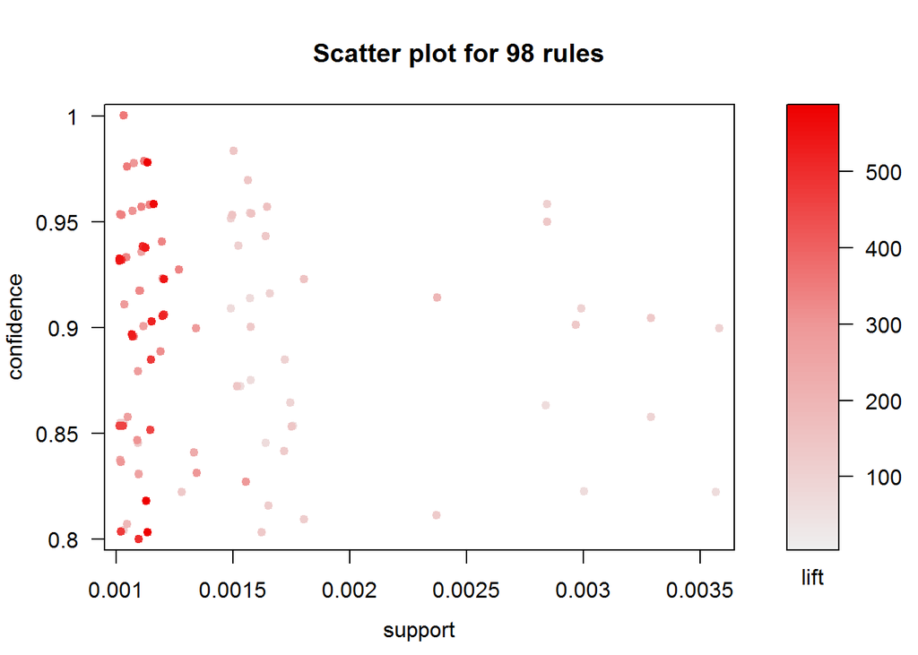

```r
plot(bookbasketrules_sorted)
```

We can enhance rules scatter plot by adding order color shading. Higher order rules have higher color shading. The highest number of order is 5.

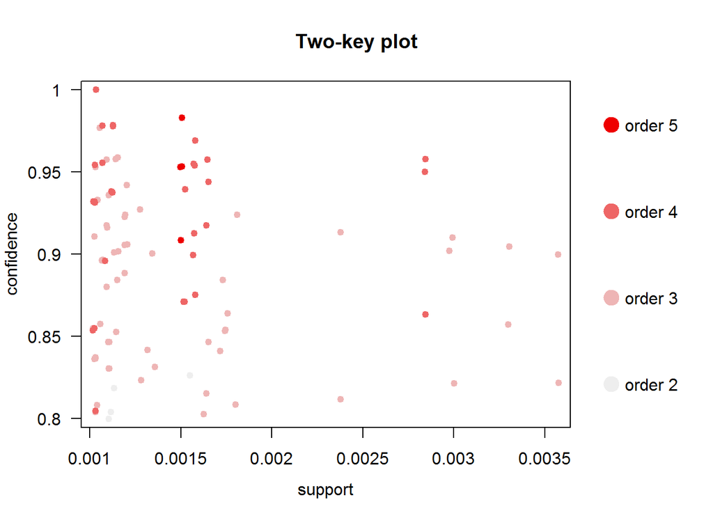

```r
##A two-key plot
plot(bookbasketrules_sorted, shading="order", control=list(main="Two-key plot"))
```

[figure not shown]

```r
## Grouped Matrix Plot
#plot(bookbasketrules_sorted, method="grouped")
plot(bookbasketrules_sorted, method="grouped", control=list(k=5))
```

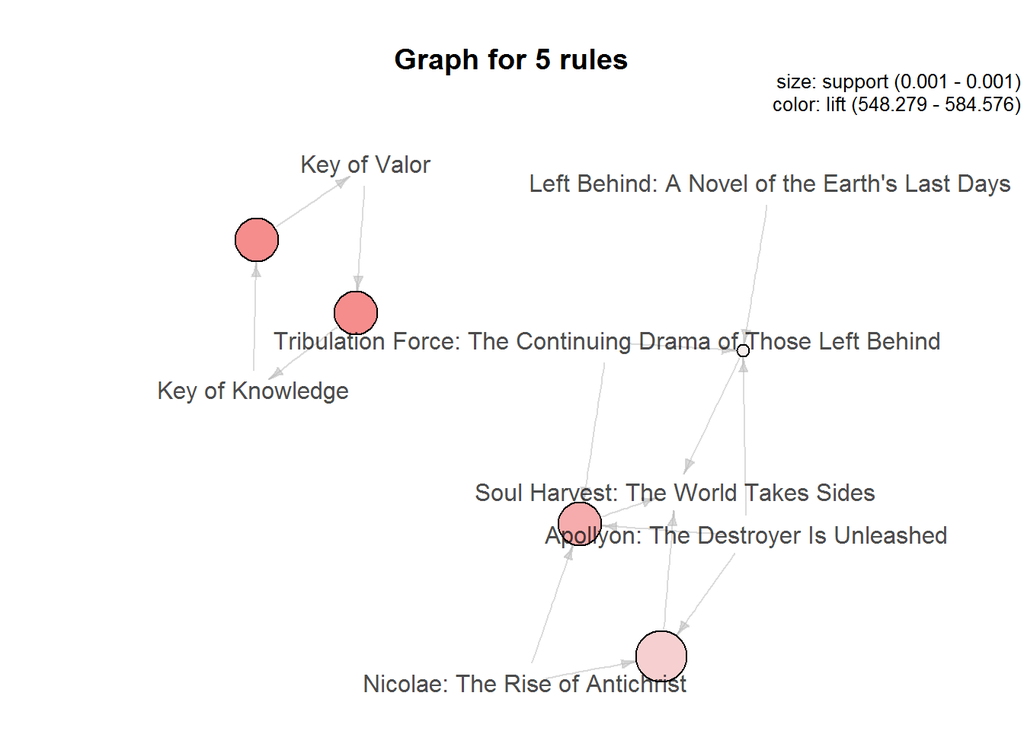

```r
plot(bookbasketrules_sorted[1:5], method="graph")
```

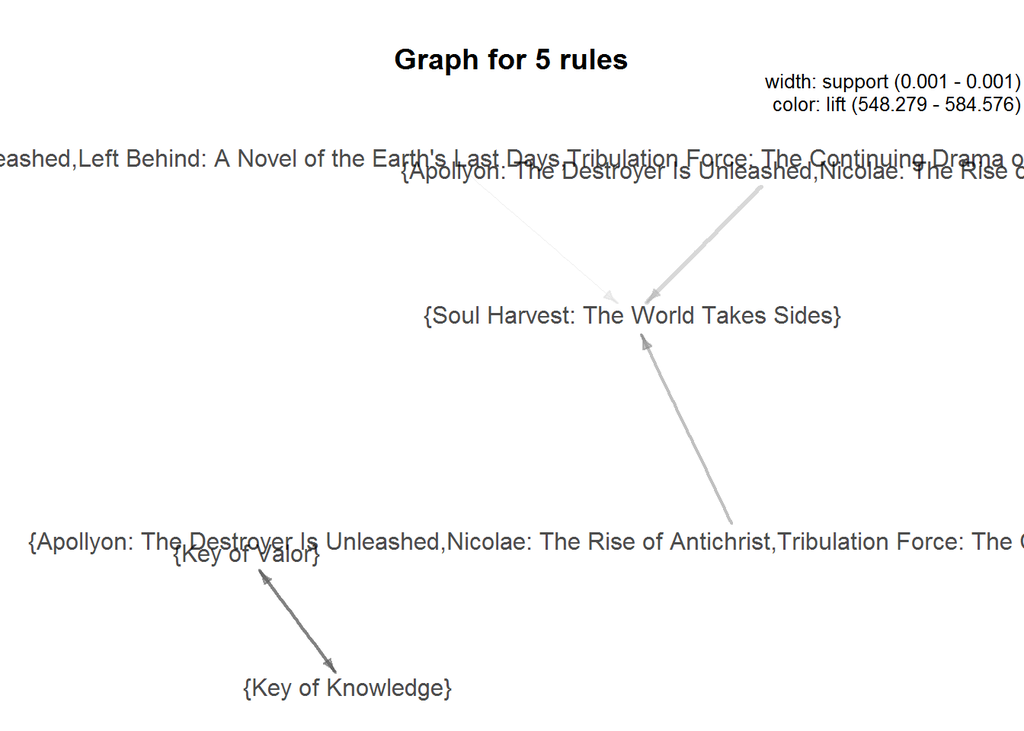

```r
plot(bookbasketrules_sorted[1:5], method="graph", control=list(type="itemsets"))
```

**If we want to exclude title “Wild Animus” then we can rerun Apriori without this title.**

```r
bookbasketsRule_noAnimus <- apriori(bookbaskets_use, parameter = list(support = 0.001, confidence = 0.8, minlen = 2, maxlen = 10),
appearance = list(none = c("Wild Animus")))
```

```
## Apriori
##
## Parameter specification:
##  confidence minval smax arem  aval originalSupport maxtime support minlen
##         0.8    0.1    1 none FALSE            TRUE       5   0.001      2
##  maxlen target   ext
##      10  rules FALSE
##
## Algorithmic control:
##  filter tree heap memopt load sort verbose
##     0.1 TRUE TRUE  FALSE TRUE    2    TRUE
##
## Absolute minimum support count: 40
##
## set item appearances ...[1 item(s)] done [0.00s].
## set transactions ...[142363 item(s), 40011 transaction(s)] done [0.66s].
## sorting and recoding items ... [1471 item(s)] done [0.05s].
## creating transaction tree ... done [0.03s].
## checking subsets of size 1 2 3 4 5 done [0.08s].
## writing ... [98 rule(s)] done [0.00s].
## creating S4 object  ... done [0.03s].
```

```r
bookbasketsRule_noAnimus_sorted <- sort(bookbasketsRule_noAnimus, by = c("lift", "confidence"))
#inspect(bookbasketsRule_noAnimus_sorted[1:20])
bookbasketsRule_noAnimus_sorted_df <- as(bookbasketsRule_noAnimus_sorted, "data.frame")
kable(bookbasketsRule_noAnimus_sorted_df[1:20,], caption = "Top Twenty Books without 'Wild Animus'")
```

Top Twenty Books without ‘Wild Animus’

|  | rules | support | confidence | lift |
| --- | --- | --- | --- | --- |
| 2 | {Key of Knowledge} => {Key of Valor} | 0.0011247 | 0.8181818 | 584.5763 |
| 1 | {Key of Valor} => {Key of Knowledge} | 0.0011247 | 0.8035714 | 584.5763 |
| 67 | {Apollyon: The Destroyer Is Unleashed,Nicolae: The Rise of Antichrist,Tribulation Force: The Continuing Drama of Those Left Behind} => {Soul Harvest: The World Takes Sides} | 0.0011247 | 0.9782609 | 575.6058 |
| 6 | {Apollyon: The Destroyer Is Unleashed,Nicolae: The Rise of Antichrist} => {Soul Harvest: The World Takes Sides} | 0.0011497 | 0.9583333 | 563.8805 |
| 71 | {Apollyon: The Destroyer Is Unleashed,Left Behind: A Novel of the Earth’s Last Days,Tribulation Force: The Continuing Drama of Those Left Behind} => {Soul Harvest: The World Takes Sides} | 0.0010247 | 0.9318182 | 548.2791 |
| 9 | {Apollyon: The Destroyer Is Unleashed,Tribulation Force: The Continuing Drama of Those Left Behind} => {Soul Harvest: The World Takes Sides} | 0.0011997 | 0.9230769 | 543.1357 |
| 68 | {Nicolae: The Rise of Antichrist,Soul Harvest: The World Takes Sides,Tribulation Force: The Continuing Drama of Those Left Behind} => {Apollyon: The Destroyer Is Unleashed} | 0.0011247 | 0.9375000 | 535.8616 |
| 72 | {Left Behind: A Novel of the Earth’s Last Days,Soul Harvest: The World Takes Sides,Tribulation Force: The Continuing Drama of Those Left Behind} => {Apollyon: The Destroyer Is Unleashed} | 0.0010247 | 0.9318182 | 532.6140 |
| 11 | {Apollyon: The Destroyer Is Unleashed,Left Behind: A Novel of the Earth’s Last Days} => {Soul Harvest: The World Takes Sides} | 0.0010747 | 0.8958333 | 527.1057 |
| 10 | {Soul Harvest: The World Takes Sides,Tribulation Force: The Continuing Drama of Those Left Behind} => {Apollyon: The Destroyer Is Unleashed} | 0.0011997 | 0.9056604 | 517.6625 |
| 7 | {Nicolae: The Rise of Antichrist,Soul Harvest: The World Takes Sides} => {Apollyon: The Destroyer Is Unleashed} | 0.0011497 | 0.9019608 | 515.5479 |
| 12 | {Left Behind: A Novel of the Earth’s Last Days,Soul Harvest: The World Takes Sides} => {Apollyon: The Destroyer Is Unleashed} | 0.0010747 | 0.8958333 | 512.0455 |
| 66 | {Apollyon: The Destroyer Is Unleashed,Soul Harvest: The World Takes Sides,Tribulation Force: The Continuing Drama of Those Left Behind} => {Nicolae: The Rise of Antichrist} | 0.0011247 | 0.9375000 | 500.1375 |
| 75 | {Left Behind: A Novel of the Earth’s Last Days,Soul Harvest: The World Takes Sides,Tribulation Force: The Continuing Drama of Those Left Behind} => {Nicolae: The Rise of Antichrist} | 0.0010247 | 0.9318182 | 497.1064 |
| 3 | {Key of Knowledge} => {Key of Light} | 0.0010997 | 0.8000000 | 492.4431 |
| 20 | {Soul Harvest: The World Takes Sides,Tribulation Force: The Continuing Drama of Those Left Behind} => {Nicolae: The Rise of Antichrist} | 0.0011997 | 0.9056604 | 483.1517 |
| 76 | {Left Behind: A Novel of the Earth’s Last Days,Nicolae: The Rise of Antichrist,Tribulation Force: The Continuing Drama of Those Left Behind} => {Soul Harvest: The World Takes Sides} | 0.0010247 | 0.8039216 | 473.0251 |
| 14 | {Apollyon: The Destroyer Is Unleashed,Tribulation Force: The Continuing Drama of Those Left Behind} => {Nicolae: The Rise of Antichrist} | 0.0011497 | 0.8846154 | 471.9246 |
| 16 | {Apollyon: The Destroyer Is Unleashed,Left Behind: A Novel of the Earth’s Last Days} => {Nicolae: The Rise of Antichrist} | 0.0010247 | 0.8541667 | 455.6808 |
| 22 | {Left Behind: A Novel of the Earth’s Last Days,Soul Harvest: The World Takes Sides} => {Nicolae: The Rise of Antichrist} | 0.0010247 | 0.8541667 | 455.6808 |

**We also want to exclude those books in a series. Then we can rerun the apriori exclude books in a series** **If we also want to exclude those books in a series then we can rerun the Apriori algorithm and exclude those books in a series** In this case when we exclude the Stephanie Plum crime series, Lord of the Ring series, Harry Potter series, The Green Miles series. We used the same 0.1% support and 80% confidence threshold.

```r
excludeList <- c("Wild Animus", "Three To Get Deadly : A Stephanie Plum Novel", "Four to Score", "Seven Up", "High Five", "Hot Six : A Stephanie Plum Novel", "Two for the Dough",
                 "The Fellowship of the Ring", "The Return of the King", "The Two Towers",
                 "Harry Potter and the Sorcerer's Stone", "Harry Potter and the Order of the Phoenix", "Harry Potter and the Prisoner of Azkaban",
                 "Harry Potter and the Chamber of Secrets", "Harry Potter and the Goblet of Fire",
                 "The Green Mile: Night Journey", "The Green Mile: Coffey on the Mile", "The Green Mile: The Bad Death of Eduard Delacroix")
bookbasketsRule_series <- apriori(bookbaskets_use, parameter = list(support = 0.001, confidence = 0.8, minlen = 2, maxlen = 5),  appearance = list(none = excludeList))
```

```
## Apriori
##
## Parameter specification:
##  confidence minval smax arem  aval originalSupport maxtime support minlen
##         0.8    0.1    1 none FALSE            TRUE       5   0.001      2
##  maxlen target   ext
##       5  rules FALSE
##
## Algorithmic control:
##  filter tree heap memopt load sort verbose
##     0.1 TRUE TRUE  FALSE TRUE    2    TRUE
##
## Absolute minimum support count: 40
##
## set item appearances ...[18 item(s)] done [0.00s].
## set transactions ...[142363 item(s), 40011 transaction(s)] done [0.44s].
## sorting and recoding items ... [1457 item(s)] done [0.03s].
## creating transaction tree ... done [0.03s].
## checking subsets of size 1 2 3 4 done [0.03s].
## writing ... [40 rule(s)] done [0.02s].
## creating S4 object  ... done [0.02s].
```

```r
summary(bookbasketsRule_series)
```

```
## set of 40 rules
##
## rule length distribution (lhs + rhs):sizes
##  2  3  4
##  4 24 12
##
##    Min. 1st Qu.  Median    Mean 3rd Qu.    Max.
##     2.0     3.0     3.0     3.2     4.0     4.0
##
## summary of quality measures:
##     support           confidence          lift
##  Min.   :0.001025   Min.   :0.8000   Min.   :121.4
##  1st Qu.:0.001025   1st Qu.:0.8504   1st Qu.:309.2
##  Median :0.001100   Median :0.8989   Median :455.1
##  Mean   :0.001117   Mean   :0.8906   Mean   :386.3
##  3rd Qu.:0.001150   3rd Qu.:0.9329   3rd Qu.:516.1
##  Max.   :0.001550   Max.   :1.0000   Max.   :584.6
##
## mining info:
##             data ntransactions support confidence
##  bookbaskets_use         40011   0.001        0.8
```

```r
bookbasketsRule_series_sorted <- sort(bookbasketsRule_series, by = c("lift", "confidence"))
#inspect(bookbasketsRule_series_sorted)
bookbasketsRule_series_sorted_df <- as(bookbasketsRule_series_sorted, "data.frame")
kable(bookbasketsRule_series_sorted_df[1:15,], caption = "Top Books not in a series")
```

|  | rules | support | confidence | lift |
| --- | --- | --- | --- | --- |
| 2 | {Key of Knowledge} => {Key of Valor} | 0.0011247 | 0.8181818 | 584.5763 |
| 1 | {Key of Valor} => {Key of Knowledge} | 0.0011247 | 0.8035714 | 584.5763 |
| 31 | {Apollyon: The Destroyer Is Unleashed,Nicolae: The Rise of Antichrist,Tribulation Force: The Continuing Drama of Those Left Behind} => {Soul Harvest: The World Takes Sides} | 0.0011247 | 0.9782609 | 575.6058 |
| 6 | {Apollyon: The Destroyer Is Unleashed,Nicolae: The Rise of Antichrist} => {Soul Harvest: The World Takes Sides} | 0.0011497 | 0.9583333 | 563.8805 |
| 35 | {Apollyon: The Destroyer Is Unleashed,Left Behind: A Novel of the Earth’s Last Days,Tribulation Force: The Continuing Drama of Those Left Behind} => {Soul Harvest: The World Takes Sides} | 0.0010247 | 0.9318182 | 548.2791 |
| 9 | {Apollyon: The Destroyer Is Unleashed,Tribulation Force: The Continuing Drama of Those Left Behind} => {Soul Harvest: The World Takes Sides} | 0.0011997 | 0.9230769 | 543.1357 |
| 32 | {Nicolae: The Rise of Antichrist,Soul Harvest: The World Takes Sides,Tribulation Force: The Continuing Drama of Those Left Behind} => {Apollyon: The Destroyer Is Unleashed} | 0.0011247 | 0.9375000 | 535.8616 |
| 36 | {Left Behind: A Novel of the Earth’s Last Days,Soul Harvest: The World Takes Sides,Tribulation Force: The Continuing Drama of Those Left Behind} => {Apollyon: The Destroyer Is Unleashed} | 0.0010247 | 0.9318182 | 532.6140 |
| 11 | {Apollyon: The Destroyer Is Unleashed,Left Behind: A Novel of the Earth’s Last Days} => {Soul Harvest: The World Takes Sides} | 0.0010747 | 0.8958333 | 527.1057 |
| 10 | {Soul Harvest: The World Takes Sides,Tribulation Force: The Continuing Drama of Those Left Behind} => {Apollyon: The Destroyer Is Unleashed} | 0.0011997 | 0.9056604 | 517.6625 |
| 7 | {Nicolae: The Rise of Antichrist,Soul Harvest: The World Takes Sides} => {Apollyon: The Destroyer Is Unleashed} | 0.0011497 | 0.9019608 | 515.5479 |
| 12 | {Left Behind: A Novel of the Earth’s Last Days,Soul Harvest: The World Takes Sides} => {Apollyon: The Destroyer Is Unleashed} | 0.0010747 | 0.8958333 | 512.0455 |
| 30 | {Apollyon: The Destroyer Is Unleashed,Soul Harvest: The World Takes Sides,Tribulation Force: The Continuing Drama of Those Left Behind} => {Nicolae: The Rise of Antichrist} | 0.0011247 | 0.9375000 | 500.1375 |
| 39 | {Left Behind: A Novel of the Earth’s Last Days,Soul Harvest: The World Takes Sides,Tribulation Force: The Continuing Drama of Those Left Behind} => {Nicolae: The Rise of Antichrist} | 0.0010247 | 0.9318182 | 497.1064 |
| 3 | {Key of Knowledge} => {Key of Light} | 0.0010997 | 0.8000000 | 492.4431 |

If we do a subset to list all rules from title “Key of Knowledge” then we get list of three rules related to title “Key of Knowledge”. We can do the same for other interesting titles. The itemset plot shows this subset of rules on one title very well.

```r
subsetRules <- subset(bookbasketsRule_series_sorted, items %in% "Key of Knowledge")
subsetRules_df <- as(subsetRules, "data.frame")
kable(subsetRules_df, caption = "Key of Knowledge subset")
```

Key of Knowledge subset

|  | rules | support | confidence | lift |
| --- | --- | --- | --- | --- |
| 2 | {Key of Knowledge} => {Key of Valor} | 0.0011247 | 0.8181818 | 584.5763 |
| 1 | {Key of Valor} => {Key of Knowledge} | 0.0011247 | 0.8035714 | 584.5763 |
| 3 | {Key of Knowledge} => {Key of Light} | 0.0010997 | 0.8000000 | 492.4431 |

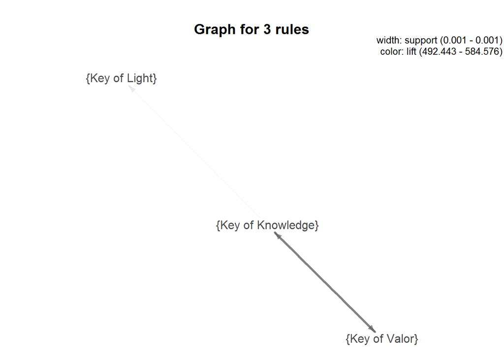

```r
plot(subsetRules, method="graph", control=list(type="itemsets"))
```

END